# Proportion of exons regions

Tomàs Montserrat Ayuso

2021/08/23

```r
library(TxDb.Mmusculus.UCSC.mm10.ensGene)
library(rtracklayer)
library(GenomicFeatures)
library(ggplot2)
```

In this document we will calculate the proportions of exons regions that span the chromosomes in *Mus musculus*. We are interested in doing two calculations:

- What proportion of the chromosome is covered by exons, no matter the strand.
- What proportion of nucleotides are covered by exons.

We start by calculating it for a single chromosome and then for each of the chromosomes, ending with a visualization of the results.

We will use the genome of *Mus musculus* version *mm10* from UCSC.

## Proportion of exons regions for a single chromosome

First of all, we load the data:

```r
txdb <- TxDb.Mmusculus.UCSC.mm10.ensGene
```

And now we get the exons:

```r
exons <- exons(txdb)
exons
```

```
## GRanges object with 348801 ranges and 1 metadata column:
##                  seqnames          ranges strand |   exon_id
##                     <Rle>       <IRanges>  <Rle> | <integer>
##        [1]           chr1 3054233-3054733      + |         1
##        [2]           chr1 3102016-3102125      + |         2
##        [3]           chr1 3466587-3466687      + |         3
##        [4]           chr1 3513405-3513553      + |         4
##        [5]           chr1 4529017-4529123      + |         5
##        ...            ...             ...    ... .       ...
##   [348797] chrUn_JH584304     55112-55701      - |    348797
##   [348798] chrUn_JH584304     56986-57151      - |    348798
##   [348799] chrUn_JH584304     58564-58835      - |    348799
##   [348800] chrUn_JH584304     58564-59690      - |    348800
##   [348801] chrUn_JH584304     59592-59667      - |    348801
##   -------
##   seqinfo: 66 sequences (1 circular) from mm10 genome
```

We will work with chromosome 1 for simplicity:

```r
chr1_exons <- exons[seqnames(exons) == "chr1"]
chr1_exons
```

```
## GRanges object with 20522 ranges and 1 metadata column:
##           seqnames              ranges strand |   exon_id
##              <Rle>           <IRanges>  <Rle> | <integer>
##       [1]     chr1     3054233-3054733      + |         1
##       [2]     chr1     3102016-3102125      + |         2
##       [3]     chr1     3466587-3466687      + |         3
##       [4]     chr1     3513405-3513553      + |         4
##       [5]     chr1     4529017-4529123      + |         5
##       ...      ...                 ...    ... .       ...
##   [20518]     chr1 195169259-195169344      - |     20518
##   [20519]     chr1 195169702-195169801      - |     20519
##   [20520]     chr1 195170991-195171168      - |     20520
##   [20521]     chr1 195176553-195176715      - |     20521
##   [20522]     chr1 195240910-195241007      - |     20522
##   -------
##   seqinfo: 66 sequences (1 circular) from mm10 genome
```

We have to collapse our exons ranges ignoring strands (if we are not interested in which strand we have the exons):

```r
chr1_exons_collapsed <- reduce(chr1_exons, ignore.strand=TRUE)
```

Then, we just have to get the total width of the exons and the chromosome and divide them:

```r
# Total width
exons_total_width <- sum(width(chr1_exons_collapsed))
chr1_length <- seqlengths(txdb)["chr1"]

# Proportion
exons_total_width/chr1_length
```

```
##       chr1
## 0.02870229
```

### Proportion of nucleotides covered by exons

If we mind which is the proportion of **nucleotides** covered by exons, then we can’t ignore the strand and, actually we have to take into account that the length of the chromosome will be doubled:

```r
# We do not have to ignore strands
chr1_exons_collapsed_strands <- reduce(chr1_exons, ignore.strand=FALSE)

# Calculate the total width and total length of nucelotides of chromosome
exons_total_width_strand <- sum(width(chr1_exons_collapsed_strands))
chr1_nucleotides <- seqlengths(txdb)["chr1"]*2

# Calculate the proportion exon nucleotide/total nucleotides
exons_total_width_strand/chr1_nucleotides
```

```
##       chr1
## 0.01455859
```

## Proportion of exons regions for each chromosome

Let’s do the same calculus for each chromosome. First, we split our exons by chromosome:

```r
exons_split_chr <- split(exons, seqnames(exons))
```

Here we have lots of sequences that are not finished, so let’s select only the chromosomes:

```r
# Extract the names of the sequences
chr_names <- names(exons_split_chr)

# Find those sequences names not belonging to a full chromosome
chr_index <- grep(pattern="_",
                  x=chr_names)

# Select chromosome names
chr_names <- chr_names[-chr_index]

# Check chromosome names
exons_split_chr <- exons_split_chr[names(exons_split_chr) == chr_names]
```

Now we can apply `reduce()` for all the elements of the list:

```r
exons_split_chr_collapsed <- lapply(exons_split_chr, reduce, ignore.strand=TRUE)
```

Then, we can find the length of the exons for each chromosome:

```r
exons_split_chr_length <- sapply(exons_split_chr_collapsed,
                                 function(x) sum(width(x)))
```

Finally, we just have to calculate the proportion of exons in each chromosome:

```r
# Create ranges for chromosomes
chr_ranges <- GRanges(seqnames=chr_names,
                      IRanges(start=1, end=seqlengths(exons)[names(seqlengths(exons))==chr_names]))

# Split these ranges by chromosome
chr_ranges_split <- split(chr_ranges, seqnames(chr_ranges))

# Calculate lengths for each chromosome
chr_length <- sapply(chr_ranges_split, function(x) sum(width(x)))

# Calculate exon proportions for each chromosome
exon_proportions <- exons_split_chr_length/chr_length
exon_proportions
```

```
##        chr1        chr2        chr3        chr4        chr5        chr6
## 0.028702289 0.045684821 0.026874673 0.039266060 0.036628884 0.031449330
##        chr7        chr8        chr9       chr10       chr11       chr12
## 0.045936379 0.031397650 0.037532701 0.030506547 0.057377057 0.023683336
##       chr13       chr14       chr15       chr16       chr17       chr18
## 0.025911913 0.025857077 0.029900469 0.028468512 0.039674821 0.024130147
##       chr19        chrX        chrY        chrM
## 0.040892804 0.025407730 0.003344488 0.942695871
```

We can visualize the data with a simple bar plot:

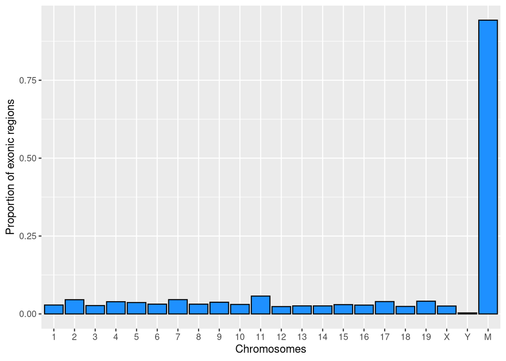

```r
# We change the names of our chromosomes to make the visualization simpler
names(exon_proportions) <- sub(pattern="chr([1-9]*|X|Y)", replacement="\\1", x=names(exon_proportions))

# Create the dataframe for using ggplot
chr_exon_prop_df <- data.frame(chr=names(exon_proportions),
                               prop=exon_proportions)

# Remove row names
rownames(chr_exon_prop_df) = NULL

# Create the correct order of the chromosomes
chr_order<-c(paste(1:19,sep=""),"X","Y","M")
chr_exon_prop_df$chr <- factor(chr_exon_prop_df$chr, levels=chr_order)

# Create the bar plot
ggplot(data=chr_exon_prop_df, aes(x=chr, y=prop)) +
  geom_bar(stat="identity", color="black", fill="dodgerblue") +
  labs(x="Chromosomes", y="Proportion of exonic regions")
```

We can remove the mitochondrial chromosome for easily comparing the rest of chromosomes:

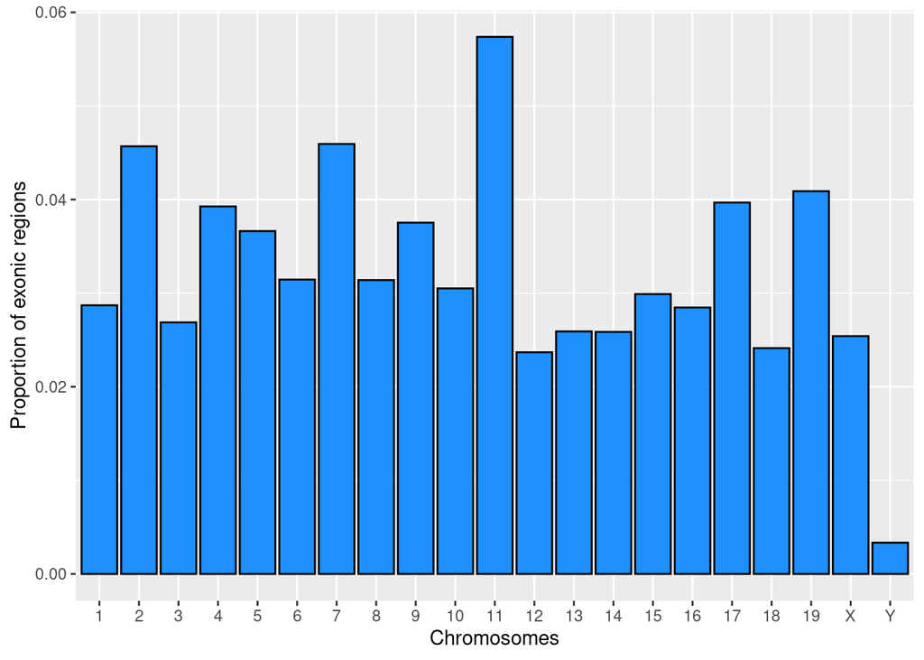

```r
# Remove mitochondrial chromosome while creating the dataframe for ggplot
chr_exon_prop_df_noM <- data.frame(chr=names(exon_proportions)[names(exon_proportions) !="M"],
                                   prop=exon_proportions[names(exon_proportions) != "M"])

# Remove row names
rownames(chr_exon_prop_df) = NULL

# Create the correct order of the chromosomes
chr_order<-c(paste(1:19,sep=""),"X","Y")
chr_exon_prop_df_noM$chr <- factor(chr_exon_prop_df_noM$chr, levels=chr_order)

# Create the bar plot
ggplot(data=chr_exon_prop_df_noM, aes(x=chr, y=prop)) +
  geom_bar(stat="identity", color="black", fill="dodgerblue") +
  labs(x="Chromosomes", y="Proportion of exonic regions")
```

### Proportion of nucleotides covered by exons

The workflow is analogous as for a single chromosome:

```r
# Do not ignore strand when merging exons regions
exons_split_chr_collapsed <- lapply(exons_split_chr, reduce, ignore.strand=FALSE)

# Calculate length of each exon region
exons_split_chr_length <- sapply(exons_split_chr_collapsed,
                                 function(x) sum(width(x)))

# Create ranges for chromosomes, doubling their length to
# take account of both strands
chr_ranges <- GRanges(seqnames=chr_names,
                      IRanges(start=1,
                              end=(seqlengths(exons)[names(seqlengths(exons))==chr_names])*2))

# Split these ranges by chromosome
chr_ranges_split <- split(chr_ranges, seqnames(chr_ranges))

# Calculate lengths for each chromosome
chr_length <- sapply(chr_ranges_split, function(x) sum(width(x)))

# Calculate exon proportions for each chromosome
exon_proportions <- exons_split_chr_length/chr_length
exon_proportions
```

```
##        chr1        chr2        chr3        chr4        chr5        chr6
## 0.014558589 0.023173551 0.013632279 0.019917089 0.018586484 0.015928623
##        chr7        chr8        chr9       chr10       chr11       chr12
## 0.023274000 0.015941025 0.019069211 0.015447359 0.029129333 0.011984872
##       chr13       chr14       chr15       chr16       chr17       chr18
## 0.013101346 0.013131554 0.015095265 0.014425147 0.020208718 0.012182782
##       chr19        chrX        chrY        chrM
## 0.020690511 0.012805051 0.001672244 0.471961470
```

We can visualize the data with a simple bar plot:

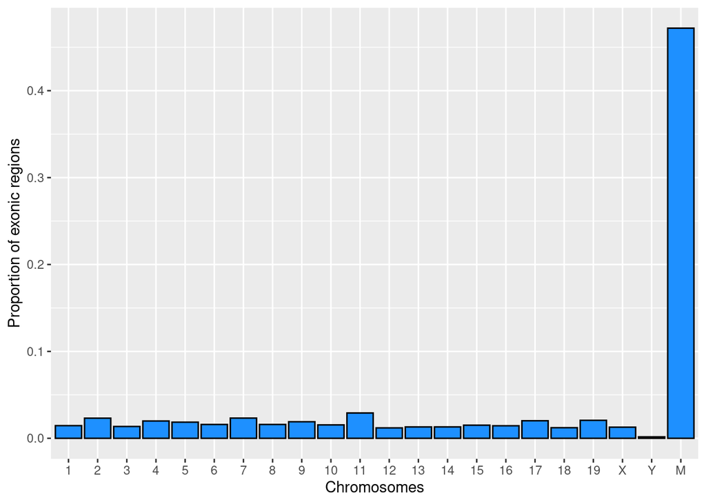

```r
# We change the names of our chromosomes to make the visualization simpler
names(exon_proportions) <- sub(pattern="chr([1-9]*|X|Y)", replacement="\\1", x=names(exon_proportions))

# Create the dataframe for using ggplot
chr_exon_prop_df <- data.frame(chr=names(exon_proportions),
                               prop=exon_proportions)

# Remove row names
rownames(chr_exon_prop_df) = NULL

# Create the correct order of the chromosomes
chr_order<-c(paste(1:19,sep=""),"X","Y","M")
chr_exon_prop_df$chr <- factor(chr_exon_prop_df$chr, levels=chr_order)

# Create the bar plot
ggplot(data=chr_exon_prop_df, aes(x=chr, y=prop)) +
  geom_bar(stat="identity", color="black", fill="dodgerblue") +
  labs(x="Chromosomes", y="Proportion of exonic regions")
```

Again, we can remove the mitochondrial chromosome for easily comparing the rest of chromosomes:

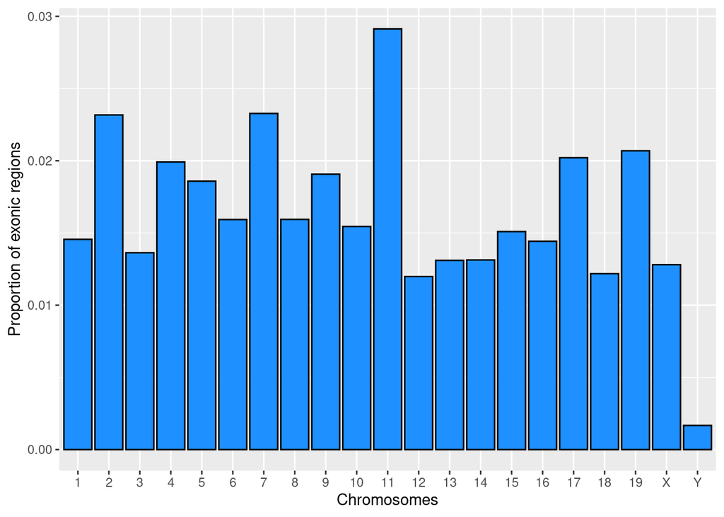

```r
# Remove mitochondrial chromosome while creating the dataframe for ggplot
chr_exon_prop_df_noM <- data.frame(chr=names(exon_proportions)[names(exon_proportions) !="M"],
                                   prop=exon_proportions[names(exon_proportions) != "M"])

# Remove row names
rownames(chr_exon_prop_df) = NULL

# Create the correct order of the chromosomes
chr_order<-c(paste(1:19,sep=""),"X","Y")
chr_exon_prop_df_noM$chr <- factor(chr_exon_prop_df_noM$chr, levels=chr_order)

# Create the bar plot
ggplot(data=chr_exon_prop_df_noM, aes(x=chr, y=prop)) +
  geom_bar(stat="identity", color="black", fill="dodgerblue") +
  labs(x="Chromosomes", y="Proportion of exonic regions")
```

## Conclusions

The proportion of exons regions in the mitochondrial chromosome is very high. Actually, almost all the mitochondrial chromosome is coding (ignoring strand). Among the rest of chromosomes, it is interesting how low is the proportion of exons regions in the Y chromosome. Also, it seems that the 11 chromosome has a slightly higher proportion of exons regions.